# p8130_hw5_rw2844

Renjie Wei

11/14/2020

# Problem 1

For this problem you will use dataset ‘Antibodies.csv’ from homework 1. In the first assignment you generated descriptive statistics and exploratory plots for the Ig-M levels by Normal vs Altered groups. The conclusion was that Ig-M distributions were both right skewed with higher levels for the Altered group. Given the non-normal distributions, now you are asked to use an alternative, non-parametric test to assess and comment on the difference in Ig-M levels between the two groups (please ignore unanswered and missing values). You can use R to perform the calculations, but make sure you state test that you used, the hypotheses, test statistic, p-value and provide interpretation in the context of the problem.

|  | Altered (N=1047) | Normal (N=410) | Unanswered/Others (N=34) |
| --- | --- | --- | --- |
| IgM |  |  |  |
| - Mean (SD) | 0.130 (0.119) | 0.110 (0.092) | 0.116 (0.068) |
| - Median/IQR | 0.097 (0.072, 0.137) | 0.081 (0.064, 0.107) | 0.094 (0.083, 0.119) |
| - Min - Max | 0.048 - 1.048 | 0.048 - 0.589 | 0.064 - 0.275 |
| - Missing | 869 | 329 | 26 |

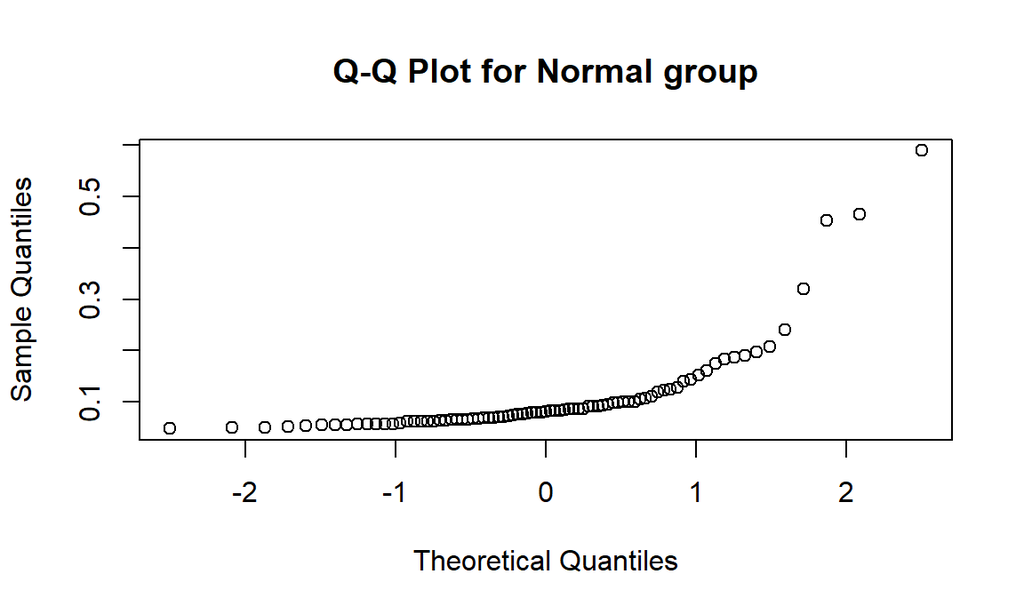

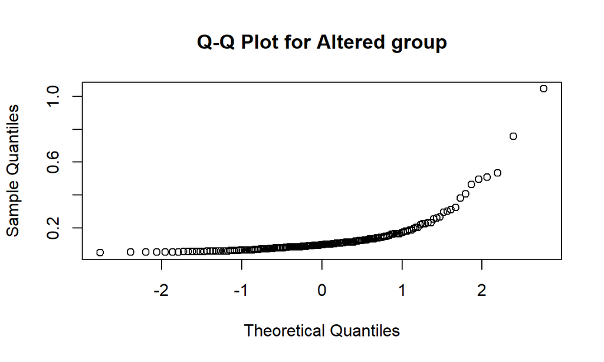

From the descriptive statistic and the qq-plots above, we can see that the IgM between two groups are skewed and un-paired. So I decided to use non-parametric method —- Wilcoxon Rank-Sum test.

Let $T_{1}$ be the sum of the ranks of the IgM levels of the Normal group, and let $T_{2}$ be the levels of the Altered group.

And the hypotheses to be tested are:

$H_0:$ the medians of the two groups are equal. $H_1:$ the medians of the two groups are not equal.

And the $T_{stat}$:
$$\begin{align}
T_{stat} = \frac{\left|T_{1}-\frac{n_{1}\left(n_{1}+n_{2}+1\right)}{2}\right|-\frac{1}{2}}{\sqrt{\left(n_{1} n_{2} / 12\right)\left(n_{1}+n_{2}+1\right)}}\\
\end{align}$$
And if ties:\
$$\begin{align}
T_{stat}=\frac{\left|T_{1}-\frac{n_{1}\left(n_{1}+n_{2}+1\right)}{2}\right|-\frac{1}{2}}{\sqrt{\left(n_{1} n_{2} / 12\right)\left[\left(n_{1}+n_{2}+1\right)-\sum_{i=1}^{g} t_{i}\left(t_{i}^{2}-1\right) /\left(n_{1}+n_{2}\right)\left(n_{1}+n_{2}-1\right)\right]}}\\
\end{align}$$
where $t_i$ refers to the number of observations with the same absolute value in the $i^{th}$ group and $g$ is the number of tied groups.

**Decision Rules:**

Under normal-approximation:$n_1~and~n_2\geq10$ , where $n_1 = 81$, and $n_2 = 178$.

Reject $H_0$ if $T_{stat}>z_{1-\alpha/2}$.

P-value = $2 \times [1-\Phi(T_{stat})]$

# Problem 2

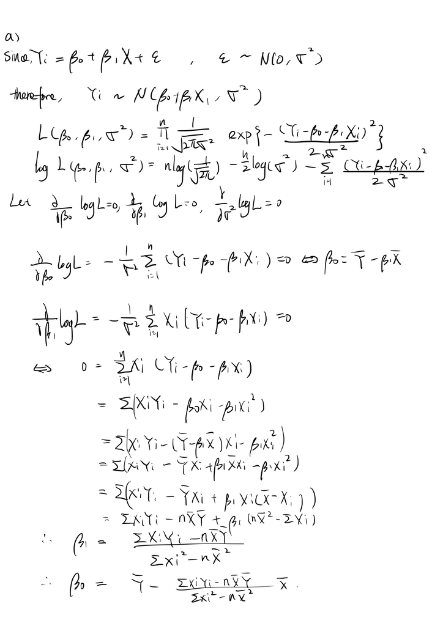

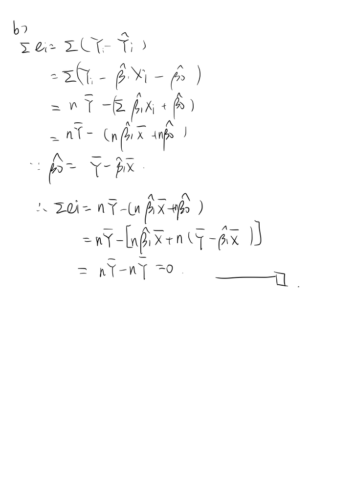

# Problem 3

## 1.

Generate a scatter plot and test whether a linear association exists between student’s ACT score (X) and GPA at the end of the freshman year (Y). Use a level of significance of 0.05. Write the hypotheses, test statistics, critical value and decision rule with interpretation in the context of the problem.

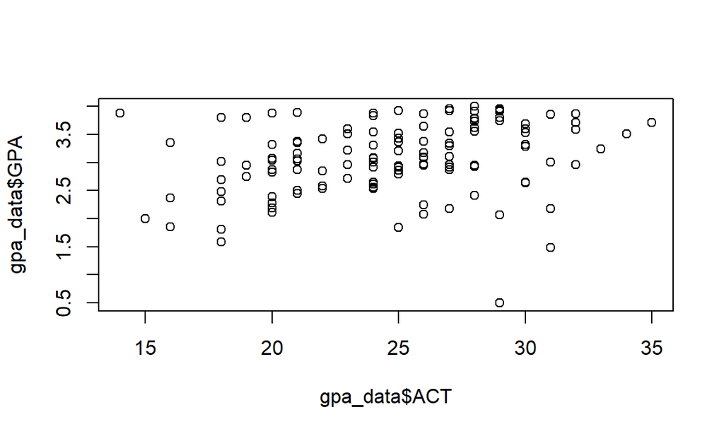

$H_0~:~\beta_1 = 0$

$H_1~:~\beta_1\ne 0$

$error~sum~of~squares(SSE) = \sum_{i=1}^k(y_{i}-\bar{y})^2$

$regression~sum~of~squares(SSR) = \sum_{i=1}^k(\hat{y_{i}}-\bar{y})^2$

$MSR = \frac{\sum_{i=1}^k(\hat{y_{i}}-\bar{y})^2}{k-1}~(k=2)$

$MSE = \frac{\sum_{i=1}^k(y_{i}-\bar{y})^2}{n-k}~(n=120)$

$F_{stat} = \frac{MSR}{MSE} \sim F(k-1,n-k)$

**Decision Rules:**

$Reject ~ H_0 ~ if ~ F_{stat}>F_{k-1,n-k,1-\alpha}$

$Fail ~ to ~ reject ~ H_0 ~ if ~F_{stat}<F_{k-1,n-k,1-\alpha}$

In our situation, $F_{stat} = 9.2402427 >F_{0.95,1,118}=3.9214782$ , we reject the Null hypothesis at 0.95 confidence level and conclude that there’s linear association between GPA and ACT.

## 2.

Write the estimated regression line equation:

$$GPA = \hat{\beta_0} + \hat{\beta_1} \times ACT$$

$$GPA = 2.114 + 0.039\times ACT$$

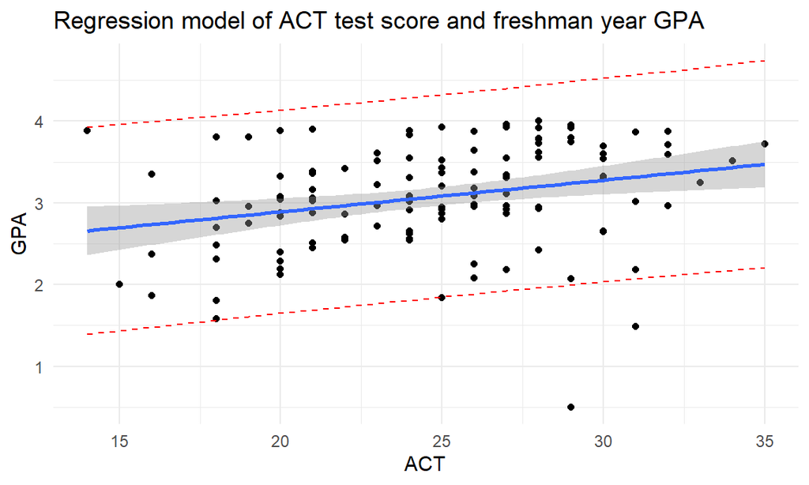

## 3.

|  | 2.5 % | 97.5 % |
| --- | --- | --- |
| (Intercept) | 1.4785902 | 2.7495084 |
| ACT | 0.0135331 | 0.0641212 |

Confidence Interval for $\beta_1$ is :
$$\hat{\beta_1} \pm t_{n-2, 1-\alpha/2} \times se(\hat{\beta_1})$$
$$= 0.0388271 \pm 1.9802722\times 0.012773$$

$$(0.014, 0.064)$$

The 95% CI for $ACT = 28$ is $(3.0613843,3.3410333)$. That means the true mean of estimator $GPA$ lies between in this range, with 95% confidence.

## 5.

The 95% CI for $ACT = 28$ is $(1.9593549,4.4430628)$. That means the true estimator $GPA$ lies between in this range, with 95% confidence.

## 6.

PI is wider than CI, because CI is the interval of the mean of the estimator while PI is the interval of the estimator itself, the standard error of the mean of the estimator is less than that of the estimator, so we got a narrower interval in CI.